# Fitting generalized binary covariance decomposition to single-cell RNA-seq data using flashier

### Assess concordance between $L$ and $\tilde{L}$

For each GEP $k$, we compute the Pearson correlation between the posterior mean estimates of $l_k$ and $\tilde{l}_k$ as a measure of concordance, and use the estimated $l_k$ as the GEP membership estimate, which is rescaled such that the maximum membership among cells is always 1.

```r
k.order <- order(fit.cov$pve, decreasing = TRUE)
fit.L <- fit.cov$L_pm[, k.order]
fit.Ltilde <- fit.cov$F_pm[, k.order]
corr <- diag(cor(fit.L, fit.Ltilde))
fit.L <- t(t(fit.L)/apply(fit.L, 2, max))
```

## Estimate the GEP signature matrix $F$

We estimate the GEP signature matrix $F$ by fitting an EBMF model to $Y$ with fixed $L=$`fit.L`.
$$\begin{align}
Y & = LF^T + \tilde{E}, \tag{5} \\
\tilde{e}_{ij} & \sim \mathrm{N}(0, \tilde{\varphi}_j^2), \tag{6} \\
f_{jk} & \sim (1-\pi_k^f) \delta_0 + \pi_k^f \: \mathrm{Laplace} (\lambda_k), \tag{7}
\end{align}$$
where $\tilde{E}$ is an $N \times J$ matrix of independent residuals $\tilde{e}_{ij}$, and $\tilde{\varphi}_j^2 > 0 \: (j = 1, \dots, J)$ are additional unknowns to be estimated. The component-specific hyper-parameters $\pi_k^f, \lambda_k$ of the point Laplace prior are estimated from data by pooling information across all genes using an empirical Bayes method. For each $k$, the genes with largest (and positive) estimates of $f_{jk}$ are interpreted as the genes driving the GEP $k$.

```r
### initialize F
init.F <- t(solve(crossprod(fit.L), crossprod(fit.L, Y)))

### backfit F
fit.snmf <- flash_init(Y, S = 1/sqrt(nrow(Y)), var_type = 2) %>%
  flash_factors_init(
    init = list(as.matrix(fit.L), as.matrix(init.F)),
    ebnm_fn = c(prior, ebnm_point_laplace)
    ) %>%
  flash_factors_fix(kset = 1:ncol(fit.L), which_dim = "loadings") %>%
  flash_backfit(extrapolate = FALSE, verbose = 1)
# Backfitting 18 factors (tolerance: 1.45e-01)...
#   Difference between iterations is within 1.0e+03...
#   Difference between iterations is within 1.0e+02...
#   Difference between iterations is within 1.0e+01...
#   Difference between iterations is within 1.0e+00...
# Wrapping up...
# Done.
```

## Improve the uncertainty quantification of GEP signatures $F$

At this point, we have already obtained a point esimate of $L$ and $F$. Although flashier also provides corresponding uncertainty estimates, mean field variational approximations, which are used in the EBMF framework, are known to underestimate uncertainty in posterior distributions. Therefore, we perform additional calculations to obtain better uncertainty quantifications of the LFC estimates $F$, which we subsequently use to compute posterior $z$-scores and other posterior quantities for $f_{jk}$. Please refer to our GBCD paper for a detailed description.

```r
J <- ncol(Y)
genes <- colnames(Y)
F.est <- matrix(0, J, ncol(fit.snmf$L_pm))
rownames(F.est) <- genes
colnames(F.est) <- colnames(fit.snmf$L_pm)
F.se <- F.est
F.z.ash <- F.est
F.lfsr.ash <- F.est

for (j in 1:J) {
  y     <- Y[,j]
  dat.x   <- as.data.frame(cbind(y, fit.snmf$L_pm))
  fit   <- lm(y ~ 0 + ., dat.x)
  coefs <- summary(fit)$coefficients
  F.est[j,] <- coefs[, "Estimate"]
  F.se[j,]  <- coefs[, "Std. Error"]
}

for(k in 1:ncol(F.est)){
  fit <- ash(F.est[,k], F.se[,k], mixcompdist = "normal", method = "shrink")
  F.z.ash[,k] <- fit$result$PosteriorMean/fit$result$PosteriorSD
  F.lfsr.ash[,k] <- fit$result$lfsr
}
```

## Save the output from the GBCD fit

Finally, we save the output from the GBCD fit, which includes (1) a point estimate of the GEP membership matrix $L$, and (2) a point estimate of the GEP signature matrix $F$ as well as the associated $z$-score and local false sign rate ($lfsr$) quantifying uncertainty in the estimation of $f_{jk}$.

For the returned GEPs by GBCD, we only keep component $k$ if the Pearson correlation between estimated $l_k$ and $\tilde{l}_k$ is greater than some pre-specified threshold (e.g., 0.8).

```r
k.idx <- which(corr > 0.8)
L.pm <- fit.snmf$L_pm[, k.idx]
colnames(L.pm) <- c("Baseline", paste0("GEP", 1:(ncol(L.pm)-1)))
F.lfc <- fit.snmf$F_pm[, k.idx]/log(2)
F.z <- F.z.ash[, k.idx]
F.lfsr <- F.lfsr.ash[, k.idx]
colnames(F.lfc) <- colnames(L.pm)
colnames(F.z) <- colnames(L.pm)
colnames(F.lfsr) <- colnames(L.pm)
fit.gbcd <- list(L = L.pm, F = list(lfc = F.lfc, z_score = F.z, lfsr = F.lfsr))
```

# Look at GBCD results for the HNSCC data

Take a look at a summary of the GBCD results.

```r
summary(fit.gbcd)
#   Length Class  Mode
# L 12078  -none- numeric
# F     3  -none- list
```

We now look at the matrix of GEP membership estimates $L$. Here we show the top rows of estimated $L$.

```r
head(round(fit.gbcd$L, 3))
#                           Baseline GEP1  GEP2 GEP3  GEP4  GEP5  GEP6  GEP7
# HNSCC16_P2_E06_S54_comb      0.914    0 0.562    0 0.327 0.328 0.260 0.000
# HNSCC16_P2_E11_S59_comb      0.683    0 0.646    0 0.419 0.000 0.000 0.273
# HNSCC16_P5_HNSCC16_P5_H07    0.925    0 0.551    0 0.000 0.299 0.000 0.000
# HNSCC16_P5_HNSCC16_P5_C09    0.867    0 0.645    0 0.469 0.000 0.265 0.000
# HNSCC16_P5_HNSCC16_P5_H05    0.946    0 0.589    0 0.000 0.269 0.000 0.425
# HNSCC16_P5_HNSCC16_P5_B04    0.735    0 0.491    0 0.792 0.000 0.000 0.302
#                            GEP8 GEP9 GEP10 GEP11 GEP12 GEP13 GEP14 GEP15 GEP16
# HNSCC16_P2_E06_S54_comb   0.000    0     0     0     0 0.403 0.000     0 0.601
# HNSCC16_P2_E11_S59_comb   0.000    0     0     0     0 0.796 0.363     0 0.628
# HNSCC16_P5_HNSCC16_P5_H07 0.001    0     0     0     0 0.000 0.000     0 0.809
# HNSCC16_P5_HNSCC16_P5_C09 0.000    0     0     0     0 0.574 0.000     0 0.600
# HNSCC16_P5_HNSCC16_P5_H05 0.238    0     0     0     0 0.000 0.000     0 0.703
# HNSCC16_P5_HNSCC16_P5_B04 0.000    0     0     0     0 0.000 0.000     0 0.491
#                           GEP17
# HNSCC16_P2_E06_S54_comb       0
# HNSCC16_P2_E11_S59_comb       0
# HNSCC16_P5_HNSCC16_P5_H07     0
# HNSCC16_P5_HNSCC16_P5_C09     0
# HNSCC16_P5_HNSCC16_P5_H05     0
# HNSCC16_P5_HNSCC16_P5_B04     0
```

Create a heatmap to visualize GEP membership estimates.

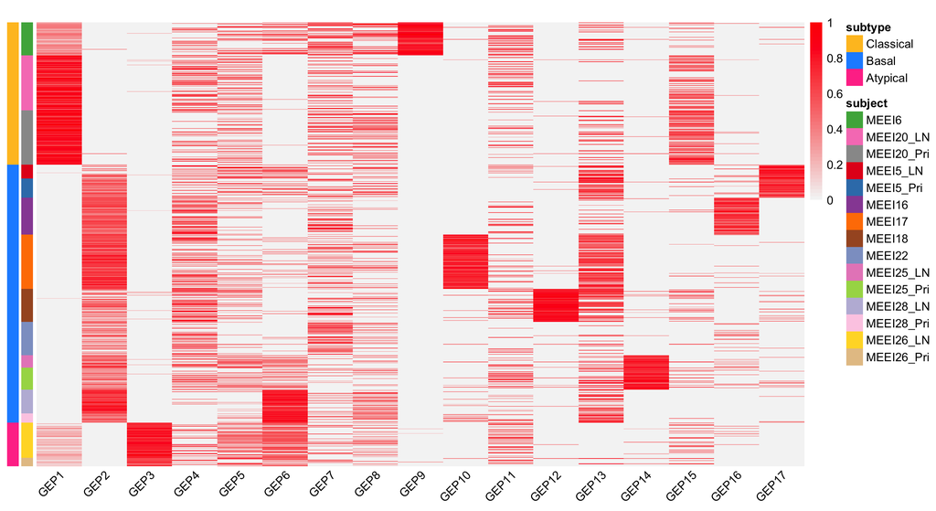

```r
### load in R packages
library(RColorBrewer)
library(pheatmap)

### add the sample and molecular subtype annotation of cells to visualize the GEP memberships
anno <- data.frame(subject=info$subject, subtype=info$subtype)
rownames(anno) <- rownames(fit.gbcd$L)
anno_colors <- list(subject=subject_col, subtype=subtype_col)
cols <- colorRampPalette(c("gray96", "red"))(50)
brks <- seq(0, 1, 0.02)

### plot the annotated heatmap of GEP memberships
pheatmap(fit.gbcd$L[order(anno$subject), -c(1)], cluster_rows = FALSE, cluster_cols = FALSE, show_rownames = FALSE, annotation_row = anno, annotation_colors = anno_colors, annotation_names_row = FALSE, angle_col = 45, fontsize = 10, color = cols, breaks = brks, main = "")
```

We next look at the matrix of GEP signature estimates $F$. Here we show the top rows of estimated $F$, and the corresponding $z$-score and $lfsr$.

```r
head(round(fit.gbcd$F$lfc, 3))
#              Baseline   GEP1   GEP2   GEP3   GEP4  GEP5   GEP6   GEP7   GEP8
# ELMO2           2.036  0.023 -1.085  0.097 -0.015 0.056  0.000 -0.001  0.044
# PNMA1           1.903  0.010 -1.436  0.050 -0.059 0.511 -0.203 -0.003  0.006
# MMP2            1.867 -1.696  2.023 -1.280  0.014 1.019 -0.008 -0.024 -0.029
# TMEM216         1.421  1.518  0.002 -0.031 -0.396 0.075 -0.009 -0.017  0.005
# TRAF3IP2-AS1    0.302  0.281  0.000  0.507  0.003 0.006 -0.002  0.000  0.007
# LOC653712       0.105  0.005  0.000 -0.020  0.001 0.182 -0.004  0.000 -0.003
#                GEP9  GEP10  GEP11  GEP12  GEP13  GEP14  GEP15  GEP16  GEP17
# ELMO2        -0.543 -0.018 -0.777 -0.056 -0.003  0.014 -0.002  0.054  0.034
# PNMA1        -0.163 -0.009  0.064  0.075  0.002  1.394  0.015 -0.006  0.003
# MMP2         -0.548 -2.064 -0.061 -0.349 -1.364  0.022 -0.006  4.129 -0.930
# TMEM216      -0.399 -0.026 -0.054 -0.013  0.000  0.335  0.019 -0.002  0.010
# TRAF3IP2-AS1  0.006  0.000  0.176  0.004  0.000  0.065  0.005  0.003  0.003
# LOC653712    -0.006 -0.001  0.011  0.001  0.000 -0.005  0.000  0.021 -0.001
```

```r
head(round(fit.gbcd$F$z_score, 3))
#              Baseline   GEP1   GEP2   GEP3   GEP4   GEP5   GEP6   GEP7   GEP8
# ELMO2           3.694  0.486 -0.402  0.654 -0.036 -0.050 -0.147 -0.032  0.457
# PNMA1           4.418 -0.367 -0.468  0.497 -1.085  1.006 -2.582 -0.188  0.150
# MMP2            6.841 -5.106  1.206 -3.198  0.302  2.001 -0.377 -0.479 -0.105
# TMEM216         3.177  1.187  0.231  0.055 -0.926  0.011 -0.430 -0.387  0.070
# TRAF3IP2-AS1    0.314  0.900  0.030  3.456  0.330 -0.261 -0.118 -0.022  0.568
# LOC653712       0.524  0.318 -0.174 -0.558 -0.184  1.861 -0.046  0.043 -0.183
#                GEP9  GEP10  GEP11  GEP12  GEP13  GEP14  GEP15  GEP16  GEP17
# ELMO2        -0.836 -0.052 -1.342 -0.156 -0.012  0.300 -0.188  0.348  0.357
# PNMA1        -0.356 -0.258  0.889  0.080  0.119  1.686  0.231 -0.181 -0.069
# MMP2         -1.267 -5.626 -0.289 -1.901 -3.102 -0.094 -0.213  6.548 -2.766
# TMEM216      -0.453 -0.370  0.127 -0.238 -0.071  0.466  0.310 -0.222  0.024
# TRAF3IP2-AS1  0.248  0.239  1.199  0.151 -0.171  0.768  0.412  0.257  0.286
# LOC653712    -0.356 -0.022  0.709  0.105 -0.044 -0.208 -0.355  0.470 -0.033
```

```r
head(round(fit.gbcd$F$lfsr, 3))
#              Baseline  GEP1  GEP2  GEP3  GEP4  GEP5  GEP6  GEP7  GEP8  GEP9
# ELMO2           0.001 0.343 0.401 0.298 0.490 0.485 0.478 0.497 0.387 0.234
# PNMA1           0.000 0.388 0.376 0.357 0.132 0.165 0.021 0.474 0.474 0.407
# MMP2            0.000 0.000 0.151 0.003 0.404 0.028 0.416 0.386 0.483 0.124
# TMEM216         0.003 0.121 0.456 0.487 0.171 0.497 0.397 0.418 0.488 0.373
# TRAF3IP2-AS1    0.425 0.190 0.495 0.003 0.391 0.423 0.484 0.498 0.347 0.443
# LOC653712       0.345 0.403 0.472 0.333 0.441 0.041 0.493 0.497 0.471 0.404
#              GEP10 GEP11 GEP12 GEP13 GEP14 GEP15 GEP16 GEP17
# ELMO2        0.494 0.074 0.477 0.499 0.441 0.460 0.415 0.424
# PNMA1        0.456 0.170 0.489 0.486 0.077 0.448 0.466 0.490
# MMP2         0.000 0.405 0.062 0.009 0.486 0.453 0.000 0.014
# TMEM216      0.422 0.461 0.459 0.492 0.384 0.423 0.456 0.496
# TRAF3IP2-AS1 0.465 0.102 0.483 0.480 0.282 0.374 0.440 0.451
# LOC653712    0.498 0.248 0.491 0.497 0.472 0.394 0.363 0.497
```

# Session info

This is the version of R and the packages that were used to generate these results.

```r
sessionInfo()
# R version 4.2.1 (2022-06-23)
# Platform: aarch64-apple-darwin20 (64-bit)
# Running under: macOS Monterey 12.4
#
# Matrix products: default
# BLAS:   /Library/Frameworks/R.framework/Versions/4.2-arm64/Resources/lib/libRblas.0.dylib
# LAPACK: /Library/Frameworks/R.framework/Versions/4.2-arm64/Resources/lib/libRlapack.dylib
#
# locale:
# [1] en_US.UTF-8/en_US.UTF-8/en_US.UTF-8/C/en_US.UTF-8/en_US.UTF-8
#
# attached base packages:
# [1] stats     graphics  grDevices utils     datasets  methods   base
#
# other attached packages:
# [1] pheatmap_1.0.12    RColorBrewer_1.1-3 ashr_2.2-54        flashier_0.2.51
# [5] magrittr_2.0.3     ebnm_1.0-46        Matrix_1.4-1
#
# loaded via a namespace (and not attached):
#  [1] Rcpp_1.0.9        horseshoe_0.2.0   invgamma_1.1      lattice_0.20-45
#  [5] tidyr_1.3.0       digest_0.6.29     utf8_1.2.2        truncnorm_1.0-8
#  [9] R6_2.5.1          evaluate_0.15     ggplot2_3.4.2     highr_0.9
# [13] pillar_1.9.0      rlang_1.1.1       rstudioapi_0.14   irlba_2.3.5
# [17] jquerylib_0.1.4   rmarkdown_2.14    splines_4.2.1     stringr_1.5.0
# [21] munsell_0.5.0     mixsqp_0.3-43     compiler_4.2.1    xfun_0.31
# [25] pkgconfig_2.0.3   SQUAREM_2021.1    htmltools_0.5.3   tidyselect_1.2.0
# [29] tibble_3.2.1      bookdown_0.28     fansi_1.0.3       dplyr_1.1.2
# [33] withr_2.5.0       grid_4.2.1        jsonlite_1.8.7    gtable_0.3.0
# [37] lifecycle_1.0.3   scales_1.2.0      cli_3.6.1         stringi_1.7.8
# [41] cachem_1.0.6      farver_2.1.1      bslib_0.4.0       generics_0.1.3
# [45] vctrs_0.6.3       trust_0.1-8       tools_4.2.1       glue_1.6.2
# [49] softImpute_1.4-1  purrr_1.0.1       parallel_4.2.1    fastmap_1.1.0
# [53] yaml_2.3.5        colorspace_2.0-3  deconvolveR_1.2-1 knitr_1.39
# [57] sass_0.4.2
```